# Introduction to spectrolab

Jose Eduardo Meireles, Anna K. Schweiger, and Jeannine Cavender-Bares

July 2026

`spectrolab` reads, processes, and visualizes data from portable spectroradiometers. Its foundation is the `spectra` S3 class: a lightweight, value-semantic container for reflectance or radiance spectra that stays dependency-light and plays well with base R. This vignette is the quickstart hub – read data in, inspect and subset it, get it back out, and compute a first result – with pointers to the focused vignettes for everything else.

The figure below plots a labeled, multi-species dataset so you can see where this is going: 50 samples across 10 groups, colored by group, with the visible, near-infrared, and short-wave infrared regions shaded behind the data.

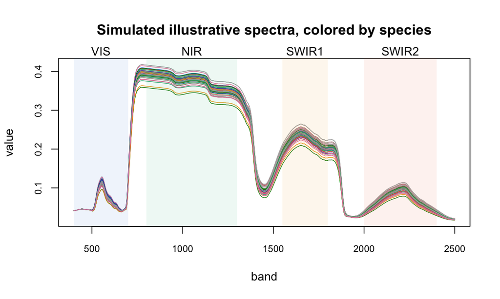

```r
# SIMULATED illustrative data: 50 samples x 2101 bands (400-2500 nm),
# grouped into 10 "species". Not real measurements.
s = as_spectra(spec_matrix_example, name_idx = 1)

plot(s, col = species_cols(s), lwd = 0.8, cex.axis = 0.8,
     main = "Simulated illustrative spectra, colored by species")
plot_regions(s, col = spec_region_tints, add = TRUE)
```

## Reading spectra

`read_spectra()` reads raw spectroradiometer files – SVC `.sig`, Spectral Evolution `.sed`, and ASD `.asd`. Pass it either a vector of file names or, more commonly, the path to a folder of files. `spectrolab` guesses the format, but you can force it with `format`. It will not descend into nested folders or mix file types in one call.

The package ships a folder of real SVC `.sig` scans of *Acer platanoides* (Norway maple) leaves. These are **radiance**, not reflectance – keep that in mind when interpreting values and indices.

```r
dir_path = system.file("extdata/Acer_example", package = "spectrolab")

# Field crews often flag files: "_WR" for white references, "_BAD" for bad
# scans. `exclude_if_matches` drops any file whose name contains these tokens.
acer = read_spectra(dir_path, exclude_if_matches = c("BAD", "WR"))

acer
```

```
#> spectra object
#> number of samples: 7
#> bands: 340.5 to 2522.8 (1024 bands, **overlap not matched**)
#> metadata: none
#> instrument: svc
#>
#>                        340.5  342    343.4  344.9  346.3  347.8  349.3  ...
#> ACPL_D2_P1_B_1_001.sig 0.0613 0.075  0.1011 0.1    0.066  0.0614 0.0574
#> ACPL_D2_P1_B_2_001.sig 0.0613 0.0833 0.1167 0.1143 0.0991 0.0737 0.0459
#> ACPL_D2_P1_M_1_000.sig 0.07   0.0889 0.083  0.0762 0.0616 0.0655 0.0765
#> ACPL_D2_P1_M_2_000.sig 0.0963 0.0917 0.0544 0.05   0.0528 0.0614 0.0459
#> ACPL_D2_P1_T_1_000.sig 0.0788 0.0917 0.0778 0.0857 0.0925 0.0737 0.0746
```

Set `extract_metadata = TRUE` to also pull each file’s header (instrument, integration times, GPS, timestamps, …) into the object’s metadata.

```r
acer_m = read_spectra(dir_path,
                      exclude_if_matches = c("BAD", "WR"),
                      extract_metadata   = TRUE)

# A few header fields for the first three scans
meta(acer_m)[1:3, c("instrument", "integration1", "units")]
```

```
#>               instrument integration1    units
#> 1 HI: 1152050 (HR-1024i)          200 Radiance
#> 2 HI: 1152050 (HR-1024i)          200 Radiance
#> 3 HI: 1152050 (HR-1024i)          150 Radiance
```

Multi-detector instruments (the SVC HR1024 uses separate Si/InGaAs sensors) also record where detectors meet. That splice provenance rides along as the `sensor_info(x)` attribute – not a `spectra` slot – and is what lets `match_sensors()` find the splice points for you. See Matching sensor overlap.

### From a matrix or data.frame

If your spectra are already in a matrix or data.frame – for example, read from a CSV – convert them with `as_spectra()`. Samples must be in rows and bands in columns, with **numeric band labels as the column headers**. Name the column holding sample names with `name_idx`, and any other non-band columns with `meta_idxs`.

```r
csv_path = system.file("extdata/spec_matrix_meta.csv", package = "spectrolab")

# check.names = FALSE keeps numeric band headers intact; otherwise R prepends
# an "X" (e.g. "X650"), which breaks the band labels.
d = read.csv(csv_path, check.names = FALSE)

# Column 3 holds sample names; columns 1-2 are metadata.
achillea = as_spectra(d, name_idx = 3, meta_idxs = c(1, 2))
achillea
```

```
#> spectra object
#> number of samples: 10
#> bands: 400 to 2400 (2001 bands)
#> metadata (2): ident, ssp
#>
#>         400                401                402
#> ACHMI_1 0.0373479128908508 0.0369863053439783 0.0380401193953007
#> ACHMI_2 0.0460840919458504 0.0453637111391286 0.0443654444079448
#> ACHMI_3 0.0405811323178848 0.0402567796762107 0.0395812484847926
#> ACHMI_4 0.0406372990791995 0.0399342035156274 0.0379345450138858
#> ACHMI_5 0.0390034916630479 0.0401309094125379 0.0410438465816645
#>         403                404                405
#> ACHMI_1 0.0394872436475697 0.0395221135988902 0.0384739968288674
#> ACHMI_2 0.0435521195217727 0.0441544684021959 0.0442455638026897
#> ACHMI_3 0.0396970622033128 0.0397878604754452 0.0381882461892174
#> ACHMI_4 0.0374293143745894 0.0379894505566575 0.0379181482886962
#> ACHMI_5 0.0408870359934367 0.0388530579686458 0.0367581698517085
#>         406                ...
#> ACHMI_1 0.0380513672514617
#> ACHMI_2 0.0420980271737174
#> ACHMI_3 0.0351967453190829
#> ACHMI_4 0.0365680899043111
#> ACHMI_5 0.0369325445228167
```

## Inspecting and subsetting

Print a `spectra`, or query its parts: `dim()`, `nrow()`, `names()` (sample names), `bands()` (band labels), `value()` (the matrix), and `meta()`.

```r
dim(acer)          # samples x bands
```

```
#> n_samples   n_bands
#>         7      1024
```

```r
nrow(acer)         # samples
```

```
#> n_samples
#>         7
```

```r
head(names(acer))  # file names became sample names
```

```
#> [1] "ACPL_D2_P1_B_1_001.sig" "ACPL_D2_P1_B_2_001.sig" "ACPL_D2_P1_M_1_000.sig"
#> [4] "ACPL_D2_P1_M_2_000.sig" "ACPL_D2_P1_T_1_000.sig" "ACPL_D2_P1_T_2_000.sig"
```

```r
range(bands(acer)) # first and last wavelength
```

```
#> [1]  340.5 2522.8
```

Subset with `[i, j]`, but note the twist: `i` matches **sample names or index**, while `j` matches **band labels, not column position**. So `x[, 600]` is the 600 nm band, and `x[, 1:5]` would (incorrectly) ask for bands *labeled* 1 through 5.

```r
# Samples by index; bands by label
vis = achillea[, 400:700]

# All samples whose name matches "ACHMI_7"
one = achillea["ACHMI_7", ]

# For non-integer band grids, select a range with bands(x, min, max)
acer_trim = acer[, bands(acer, 400, 2400)]
```

```
#> Selected band label(s) 1005.5 match more than one band (duplicated wavelengths); all matching bands were returned. Run match_sensors() to splice overlapping sensors into unique, increasing bands.
```

`subset_by()` keeps only groups with between `n_min` and `n_max` members – handy for dropping under-replicated groups before summarizing.

```r
# Keep only species with at least 3 samples (all 10 qualify here)
common = subset_by(s, by = names(s), n_min = 3, n_max = Inf)
dim(common)
```

```
#> n_samples   n_bands
#>        50      2101
```

**A quick QA beat.** Plotting a quantile envelope over the raw lines makes outliers pop out – a scan that strays outside the bulk of the data is easy to spot visually before it contaminates a summary.

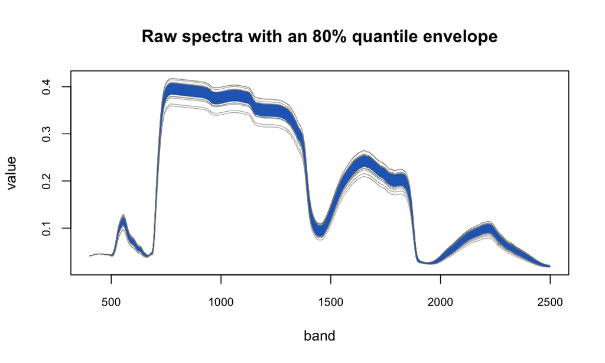

```r
plot(s, col = spec_muted, lwd = 0.5, cex.axis = 0.8,
     main = "Raw spectra with an 80% quantile envelope")
plot_quantile(s, total_prob = 0.8, col = spec_seq(3)[2], border = FALSE, add = TRUE)
```

For large datasets, `plot_interactive()` opens a Shiny app to scroll and zoom through spectra one screenful at a time. It is interactive, so it cannot render in a static vignette; run it in an R session:

```r
plot_interactive(s)
```

## Getting data out

Three ways to hand spectra to other tools:

```r
# 1. A plain matrix: bands in columns, samples in rownames. Drops metadata.
m = as.matrix(achillea, fix_names = "none")
m[1:3, 1:3]
```

```
#>                400        401        402
#> ACHMI_1 0.03734791 0.03698631 0.03804012
#> ACHMI_2 0.04608409 0.04536371 0.04436544
#> ACHMI_3 0.04058113 0.04025678 0.03958125
```

```r
# 2. A data.frame, keeping metadata columns by default.
df = as.data.frame(achillea, fix_names = "none")
df[1:3, 1:4]
```

```
#>   sample_name ident                   ssp        400
#> 1     ACHMI_1 10526 Achillea millefolium  0.03734791
#> 2     ACHMI_2 10527 Achillea millefolium  0.04608409
#> 3     ACHMI_3 10528 Achillea millefolium  0.04058113
```

```r
# 3. Long/tidy form: one row per sample-and-band (ideal for ggplot2).
lng = to_long(s)
head(lng, 3)
```

```
#>   sample_name band      value
#> 1   species_7  400 0.04099999
#> 2   species_8  400 0.04099620
#> 3   species_5  400 0.04100099
```

`as_tibble()` and `autoplot()` build on `to_long()`; see Visualizing spectral variation.

## A first result: spectral indices

Two-band normalized-difference indices are one line each. The built-in `spectral_index` list carries ready-to-use functions – call them directly on a `spectra` object, which returns one value per sample.

```r
ndvi = spectral_index$ndvi(s)   # (R800 - R680) / (R800 + R680)
pri  = spectral_index$pri(s)    # (R570 - R531) / (R570 + R531)

summary(ndvi)
```

```
#>    Min. 1st Qu.  Median    Mean 3rd Qu.    Max.
#>  0.7854  0.7940  0.7959  0.7957  0.7976  0.8016
```

Build your own with `make_spectral_index(band1, band2)`, which returns a function you can reuse. Here is a green-band NDVI variant:

```r
gndvi = make_spectral_index(800, 550)
head(round(gndvi(s), 3))
```

```
#>  species_7  species_8  species_5  species_7 species_10  species_1
#>      0.558      0.563      0.544      0.566      0.562      0.557
```

The index engine snaps each requested wavelength to the **nearest available band**, but only within `tolerance` (default 1, in band units). If no band falls within `tolerance` it errors rather than silently using a distant band – so widen `tolerance` for coarse or resampled grids. Indices also require strictly increasing bands: splice sensor overlaps first (see below).

For the simulated data, NDVI clusters high (dense-canopy-like reflectance) as expected; PRI is centered near zero, consistent with its narrow physiological range.

## Good to know

A few intentional behaviors that can still surprise you.

**Duplicate sample names *and* duplicate band labels are both allowed.** Several scans of one individual share a name; raw SVC files legitimately carry the same wavelength on both sides of a sensor overlap before splicing. Subsetting a duplicated label returns *all* matches (and says so). But most transforms (`smooth()`, `normalize()`, `resample()`, spectral indices) require strictly increasing bands and will error on raw, unspliced overlaps – run `match_sensors()` first.

**`s1 + s2` is arithmetic; `combine()` stacks.** The overloaded operators (`+ - * / ^`) act element-wise on two `spectra` of identical dimensions and bands, and keep names/metadata only when both sides agree (otherwise they clear with a warning). To row-bind two datasets – bands checked for an exact match, metadata columns merged by name – use `combine()` (or its shorthands `c()` / `rbind()`).

**Comparison operators return a bare matrix.** `s1 > s2`, `s1 == s2`, and friends return a logical samples-by-bands matrix, not a `spectra` – a boolean “spectrum” is not meaningful. Only the arithmetic operators return `spectra`.

## Where to go next

- Matching sensor overlap – splice multi-detector data.
- Cleaning & standardizing – smooth, trim, normalize.
- Combining & harmonizing – stack and align datasets.
- Estimating leaf traits with PLSR – a modeling workflow.
- Visualizing spectral variation – tidy data and `ggplot2`.